# Data Science in Saudi Arabia

# Overview

Recently, the technologies have grown and developed at a rapid pace. Since the technologies are directly related to our progress, much people are interested in different fields of technologies. Today, many Saudis interested in the field of data science and machine learning want to learn about the state of data science and machine learning in Saudi Arabia.

This report presents a general overview about the status of the data science and machine learning in Saudi Arabia and may help the new people in the fields to break into the fields. The report is created based on ["*2020 Kaggle Machine Learning & Data Science Survey*"](https://www.kaggle.com/c/kaggle-survey-2020). The goal of the conducted survey is to establish a comprehensive view of the state of data science and machine learning fields and explore what is happening in these fields. The survey received responses from 20036 Kaggle members, and this report focuses on the respondents from Saudi Arabia. The report will display the respondents’ skills, education, employment, and the technologies used to perform their work.

## The Survey questions and Answers

The list of answer choices for every question is available [here](https://www.kaggle.com/c/kaggle-survey-2020/data).

## Import Libraries and Show the Data

```python
#Import libraries
import numpy as np
import pandas as pd
import matplotlib.pyplot as plt
import matplotlib.ticker as ticker
```

```python
#Read CSV file
df2020 = pd.read_csv('kaggle_survey_2020_responses.csv') # Kaggle 2020 survey
```

```python
df2020.head()
```

|  | Time from Start to Finish (seconds) | Q1 | Q2 | Q3 | Q4 | Q5 | Q6 | Q7_Part_1 | Q7_Part_2 | Q7_Part_3 | ... | Q35_B_Part_2 | Q35_B_Part_3 | Q35_B_Part_4 | Q35_B_Part_5 | Q35_B_Part_6 | Q35_B_Part_7 | Q35_B_Part_8 | Q35_B_Part_9 | Q35_B_Part_10 | Q35_B_OTHER |
| --- | --- | --- | --- | --- | --- | --- | --- | --- | --- | --- | --- | --- | --- | --- | --- | --- | --- | --- | --- | --- | --- |
| 0 | Duration (in seconds) | What is your age (# years)? | What is your gender? - Selected Choice | In which country do you currently reside? | What is the highest level of formal education ... | Select the title most similar to your current ... | For how many years have you been writing code ... | What programming languages do you use on a reg... | What programming languages do you use on a reg... | What programming languages do you use on a reg... | ... | In the next 2 years, do you hope to become mor... | In the next 2 years, do you hope to become mor... | In the next 2 years, do you hope to become mor... | In the next 2 years, do you hope to become mor... | In the next 2 years, do you hope to become mor... | In the next 2 years, do you hope to become mor... | In the next 2 years, do you hope to become mor... | In the next 2 years, do you hope to become mor... | In the next 2 years, do you hope to become mor... | In the next 2 years, do you hope to become mor... |
| 1 | 1838 | 35-39 | Man | Colombia | Doctoral degree | Student | 5-10 years | Python | R | SQL | ... | NaN | NaN | NaN | TensorBoard | NaN | NaN | NaN | NaN | NaN | NaN |
| 2 | 289287 | 30-34 | Man | United States of America | Master’s degree | Data Engineer | 5-10 years | Python | R | SQL | ... | NaN | NaN | NaN | NaN | NaN | NaN | NaN | NaN | NaN | NaN |
| 3 | 860 | 35-39 | Man | Argentina | Bachelor’s degree | Software Engineer | 10-20 years | NaN | NaN | NaN | ... | NaN | NaN | NaN | NaN | NaN | NaN | NaN | NaN | None | NaN |
| 4 | 507 | 30-34 | Man | United States of America | Master’s degree | Data Scientist | 5-10 years | Python | NaN | SQL | ... | NaN | NaN | NaN | NaN | NaN | NaN | NaN | NaN | NaN | NaN |

5 rows × 355 columns

```python
# Kaggler from Saudi Arabia
saudi_df2020 = df2020.loc[1:][df2020.loc[1:]['Q3'] == 'Saudi Arabia']
saudi_df2020.head()
```

|  | Time from Start to Finish (seconds) | Q1 | Q2 | Q3 | Q4 | Q5 | Q6 | Q7_Part_1 | Q7_Part_2 | Q7_Part_3 | ... | Q35_B_Part_2 | Q35_B_Part_3 | Q35_B_Part_4 | Q35_B_Part_5 | Q35_B_Part_6 | Q35_B_Part_7 | Q35_B_Part_8 | Q35_B_Part_9 | Q35_B_Part_10 | Q35_B_OTHER |
| --- | --- | --- | --- | --- | --- | --- | --- | --- | --- | --- | --- | --- | --- | --- | --- | --- | --- | --- | --- | --- | --- |
| 56 | 739 | 35-39 | Man | Saudi Arabia | Bachelor’s degree | Other | I have never written code | NaN | NaN | NaN | ... | NaN | NaN | NaN | NaN | NaN | NaN | NaN | NaN | NaN | NaN |
| 158 | 918 | 25-29 | Woman | Saudi Arabia | Master’s degree | Data Analyst | 5-10 years | Python | NaN | SQL | ... | NaN | NaN | NaN | TensorBoard | NaN | NaN | NaN | NaN | NaN | NaN |
| 242 | 411 | 25-29 | Woman | Saudi Arabia | Professional degree | Data Scientist | 1-2 years | Python | R | SQL | ... | NaN | NaN | NaN | NaN | NaN | NaN | NaN | NaN | NaN | NaN |
| 381 | 298 | 45-49 | Man | Saudi Arabia | Bachelor’s degree | Currently not employed | I have never written code | NaN | NaN | NaN | ... | NaN | NaN | NaN | NaN | NaN | NaN | NaN | NaN | NaN | NaN |
| 523 | 805 | 25-29 | Man | Saudi Arabia | Master’s degree | Currently not employed | < 1 years | Python | NaN | SQL | ... | NaN | NaN | NaN | NaN | NaN | NaN | NaN | NaN | None | NaN |

5 rows × 355 columns

```python
# Kaggler from other countries
other_df2020 = df2020.loc[1:][df2020.loc[1:]['Q3'] != 'Saudi Arabia']
other_df2020.head()
```

|  | Time from Start to Finish (seconds) | Q1 | Q2 | Q3 | Q4 | Q5 | Q6 | Q7_Part_1 | Q7_Part_2 | Q7_Part_3 | ... | Q35_B_Part_2 | Q35_B_Part_3 | Q35_B_Part_4 | Q35_B_Part_5 | Q35_B_Part_6 | Q35_B_Part_7 | Q35_B_Part_8 | Q35_B_Part_9 | Q35_B_Part_10 | Q35_B_OTHER |
| --- | --- | --- | --- | --- | --- | --- | --- | --- | --- | --- | --- | --- | --- | --- | --- | --- | --- | --- | --- | --- | --- |
| 1 | 1838 | 35-39 | Man | Colombia | Doctoral degree | Student | 5-10 years | Python | R | SQL | ... | NaN | NaN | NaN | TensorBoard | NaN | NaN | NaN | NaN | NaN | NaN |
| 2 | 289287 | 30-34 | Man | United States of America | Master’s degree | Data Engineer | 5-10 years | Python | R | SQL | ... | NaN | NaN | NaN | NaN | NaN | NaN | NaN | NaN | NaN | NaN |
| 3 | 860 | 35-39 | Man | Argentina | Bachelor’s degree | Software Engineer | 10-20 years | NaN | NaN | NaN | ... | NaN | NaN | NaN | NaN | NaN | NaN | NaN | NaN | None | NaN |
| 4 | 507 | 30-34 | Man | United States of America | Master’s degree | Data Scientist | 5-10 years | Python | NaN | SQL | ... | NaN | NaN | NaN | NaN | NaN | NaN | NaN | NaN | NaN | NaN |
| 5 | 78 | 30-34 | Man | Japan | Master’s degree | Software Engineer | 3-5 years | Python | NaN | NaN | ... | NaN | NaN | NaN | NaN | NaN | NaN | NaN | NaN | NaN | NaN |

5 rows × 355 columns

```python
saudi_df2020 = saudi_df2020.reset_index()
```

```python
#006C35
##004c35 font
##bfffec
#80ffd9
```

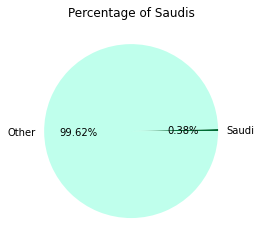

```python
# Show the percentage of Saudies in a pie chart
plt.pie([saudi_df2020.shape[0]/ df2020.shape[0]*100, other_df2020.shape[0]/ df2020.shape[0]*100],
        labels = ['Saudi', 'Other'], colors = ['#006C35', '#bfffec'], autopct='%1.2f%%')
plt.title('Percentage of Saudis')
plt.show()
```

We can see that Saudis are only 0.38% of all participants.

## 1. Demographic Data

### 1.1. Gender

```python
#Create a dataframe for gender counts
gender = pd.DataFrame(saudi_df2020.groupby('Q2').count()['Q1']).reset_index()
gender
```

|  | Q2 | Q1 |
| --- | --- | --- |
| 0 | Man | 55 |
| 1 | Prefer not to say | 1 |
| 2 | Woman | 20 |

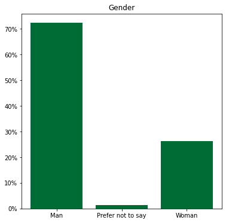

```python
# Show female and male percentage in a bar chart
plt.figure(figsize = (6,6))
plt.bar(gender['Q2'],gender['Q1']/saudi_df2020.shape[0]*100, color = '#006C35')
plt.gca().yaxis.set_major_formatter(ticker.PercentFormatter(decimals=0.5))
plt.title('Gender')
plt.show()
```

There is a big difference between the number of males and the number of females who are working in the field of data science. The percentage of males is 72%.

### 1.2. Age

```python
#Age Count
age = pd.DataFrame(saudi_df2020.groupby('Q1').count()['Q2']).reset_index()
age
```

|  | Q1 | Q2 |
| --- | --- | --- |
| 0 | 18-21 | 2 |
| 1 | 22-24 | 11 |
| 2 | 25-29 | 15 |
| 3 | 30-34 | 7 |
| 4 | 35-39 | 19 |
| 5 | 40-44 | 15 |
| 6 | 45-49 | 5 |
| 7 | 50-54 | 1 |
| 8 | 55-59 | 1 |

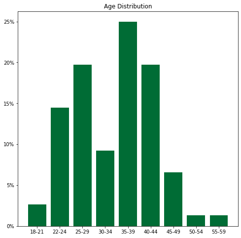

```python
# Show age distribution
plt.figure(figsize = (8,8))
plt.bar(age['Q1'], age['Q2']/saudi_df2020.shape[0]*100, color = '#006C35')
plt.gca().yaxis.set_major_formatter(ticker.PercentFormatter(decimals=0.5))
plt.title('Age Distribution')
plt.show()
```

The largest percentage of the participants are in their late thirties, and they are 25% of the participants. In general, most of the participants are between 22 and 44 years old.

## 2. Education

### 2.1. Education Level

```python
# Create a dataframe for education level
edu = pd.DataFrame(saudi_df2020.groupby(['Q4']).count()['Q2']/saudi_df2020.shape[0]*100).reset_index()
# Sort dataframe
edu = edu.sort_values('Q2')
edu
```

|  | Q4 | Q2 |
| --- | --- | --- |
| 5 | Some college/university study without earning ... | 1.315789 |
| 3 | No formal education past high school | 2.631579 |
| 4 | Professional degree | 7.894737 |
| 1 | Doctoral degree | 17.105263 |
| 0 | Bachelor’s degree | 32.894737 |
| 2 | Master’s degree | 36.842105 |

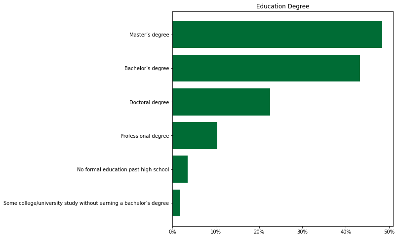

```python
# Show education level bar chart
plt.figure(figsize = (8,8))
plt.barh(edu['Q4'], edu['Q2']/saudi_df2020.shape[0]*100, color = '#006C35')
plt.gca().xaxis.set_major_formatter(ticker.PercentFormatter(decimals=0.5))
plt.title('Education Degree')
plt.show()
```

### 2.2. Learning Resources

```python
# Create a dataframe for learning resources in Saudi Arabia
course_list = ['Coursera', 'edX', 'Kaggle Learn Courses','DataCamp','Fast.ai','Udacity', 'Udemy',
 'LinkedIn Learning', 'Cloud-certification programs', 'University Courses', 'None', 'Other']

count_list = [saudi_df2020['Q37_Part_1'].count()/saudi_df2020.shape[0]*100,
              saudi_df2020['Q37_Part_2'].count()/saudi_df2020.shape[0]*100,
              saudi_df2020['Q37_Part_3'].count()/saudi_df2020.shape[0]*100,
              saudi_df2020['Q37_Part_4'].count()/saudi_df2020.shape[0]*100,
              saudi_df2020['Q37_Part_5'].count()/saudi_df2020.shape[0]*100,
              saudi_df2020['Q37_Part_6'].count()/saudi_df2020.shape[0]*100,
              saudi_df2020['Q37_Part_7'].count()/saudi_df2020.shape[0]*100,
              saudi_df2020['Q37_Part_8'].count()/saudi_df2020.shape[0]*100,
              saudi_df2020['Q37_Part_9'].count()/saudi_df2020.shape[0]*100,
              saudi_df2020['Q37_Part_10'].count()/saudi_df2020.shape[0]*100,
              saudi_df2020['Q37_Part_11'].count()/saudi_df2020.shape[0]*100,
              saudi_df2020['Q37_OTHER'].count()/saudi_df2020.shape[0]*100]

course = pd.DataFrame({'Course':course_list, 'Frequency': count_list})
course
```

|  | Course | Frequency |
| --- | --- | --- |
| 0 | Coursera | 21.052632 |
| 1 | edX | 11.842105 |
| 2 | Kaggle Learn Courses | 23.684211 |
| 3 | DataCamp | 18.421053 |
| 4 | Fast.ai | 3.947368 |
| 5 | Udacity | 26.315789 |
| 6 | Udemy | 26.315789 |
| 7 | LinkedIn Learning | 5.263158 |
| 8 | Cloud-certification programs | 3.947368 |
| 9 | University Courses | 7.894737 |
| 10 | None | 2.631579 |
| 11 | Other | 3.947368 |

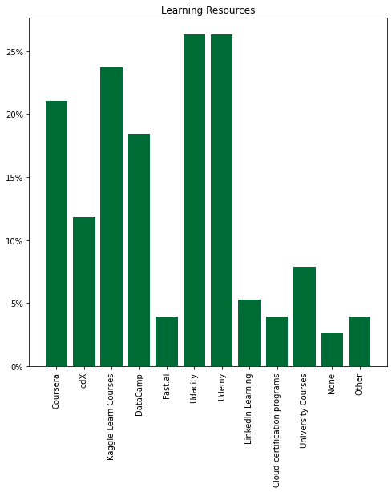

```python
# Show learning resources bar chart
plt.figure(figsize = (8,8))
plt.bar(course['Course'], course['Frequency'], color = '#006C35')
plt.gca().yaxis.set_major_formatter(ticker.PercentFormatter(decimals=0.5))
plt.title('Learning Resources')
plt.xticks(rotation=90)
plt.show()
```

```python
# Create a dataframe for learning resources in other countries
course_list2 = ['Coursera', 'edX', 'Kaggle Learn Courses','DataCamp','Fast.ai','Udacity', 'Udemy',
 'LinkedIn Learning', 'Cloud-certification programs', 'University Courses', 'None', 'Other']

count_list2 = [other_df2020['Q37_Part_1'].count()/other_df2020.shape[0]*100,
              other_df2020['Q37_Part_2'].count()/other_df2020.shape[0]*100,
              other_df2020['Q37_Part_3'].count()/other_df2020.shape[0]*100,
              other_df2020['Q37_Part_4'].count()/other_df2020.shape[0]*100,
              other_df2020['Q37_Part_5'].count()/other_df2020.shape[0]*100,
              other_df2020['Q37_Part_6'].count()/other_df2020.shape[0]*100,
              other_df2020['Q37_Part_7'].count()/other_df2020.shape[0]*100,
              other_df2020['Q37_Part_8'].count()/other_df2020.shape[0]*100,
              other_df2020['Q37_Part_9'].count()/other_df2020.shape[0]*100,
              other_df2020['Q37_Part_10'].count()/other_df2020.shape[0]*100,
              other_df2020['Q37_Part_11'].count()/other_df2020.shape[0]*100,
              other_df2020['Q37_OTHER'].count()/other_df2020.shape[0]*100]

course2 = pd.DataFrame({'Course':course_list, 'Frequency': count_list})
course2
```

|  | Course | Frequency |
| --- | --- | --- |
| 0 | Coursera | 21.052632 |
| 1 | edX | 11.842105 |
| 2 | Kaggle Learn Courses | 23.684211 |
| 3 | DataCamp | 18.421053 |
| 4 | Fast.ai | 3.947368 |
| 5 | Udacity | 26.315789 |
| 6 | Udemy | 26.315789 |
| 7 | LinkedIn Learning | 5.263158 |
| 8 | Cloud-certification programs | 3.947368 |
| 9 | University Courses | 7.894737 |
| 10 | None | 2.631579 |
| 11 | Other | 3.947368 |

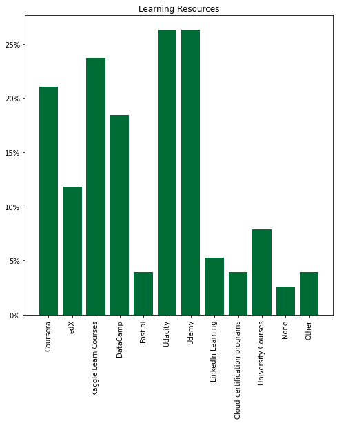

```python
# Show learning resources bar chart
plt.figure(figsize = (8,8))
plt.bar(course2['Course'], course2['Frequency'], color = '#006C35')
plt.gca().yaxis.set_major_formatter(ticker.PercentFormatter(decimals=0.5))
plt.title('Learning Resources')
plt.xticks(rotation=90)
plt.show()
```

### 2.3 Favorite Media Sources

```python
#fill empty field with None
for i in range(len(saudi_df2020)):
    if (pd.isnull(saudi_df2020.loc[i, 'Q39_Part_1']) & pd.isnull(saudi_df2020.loc[i, 'Q39_Part_2'])
       & pd.isnull(saudi_df2020.loc[i, 'Q39_Part_3'])& pd.isnull(saudi_df2020.loc[i, 'Q39_Part_4'])
       & pd.isnull(saudi_df2020.loc[i, 'Q39_Part_5'])& pd.isnull(saudi_df2020.loc[i, 'Q39_Part_6'])
       & pd.isnull(saudi_df2020.loc[i, 'Q39_Part_7'])& pd.isnull(saudi_df2020.loc[i, 'Q39_Part_8'])
       & pd.isnull(saudi_df2020.loc[i, 'Q39_Part_9'])& pd.isnull(saudi_df2020.loc[i, 'Q39_Part_10'])
       & pd.isnull(saudi_df2020.loc[i, 'Q39_Part_11'])& pd.isnull(saudi_df2020.loc[i, 'Q39_OTHER'])):
        saudi_df2020.loc[i, 'Q39_Part_11'] = 'None'
```

```python
# Create a dataframe for favorite media sources
media_list = ['Twitter', 'Email newsletter', 'Reddit','Kaggle','Course Forums','YouTube', 'Podcasts',
 'Blogs', 'Journal Publications', 'Slack Communitiess', 'None', 'Other']


count_list = [saudi_df2020['Q39_Part_1'].count()/saudi_df2020.shape[0]*100,
              saudi_df2020['Q39_Part_2'].count()/saudi_df2020.shape[0]*100,
              saudi_df2020['Q39_Part_3'].count()/saudi_df2020.shape[0]*100,
              saudi_df2020['Q39_Part_4'].count()/saudi_df2020.shape[0]*100,
              saudi_df2020['Q39_Part_5'].count()/saudi_df2020.shape[0]*100,
              saudi_df2020['Q39_Part_6'].count()/saudi_df2020.shape[0]*100,
              saudi_df2020['Q39_Part_7'].count()/saudi_df2020.shape[0]*100,
              saudi_df2020['Q39_Part_8'].count()/saudi_df2020.shape[0]*100,
              saudi_df2020['Q39_Part_9'].count()/saudi_df2020.shape[0]*100,
              saudi_df2020['Q39_Part_10'].count()/saudi_df2020.shape[0]*100,
              saudi_df2020['Q39_Part_11'].count()/saudi_df2020.shape[0]*100,
              saudi_df2020['Q39_OTHER'].count()/saudi_df2020.shape[0]*100]

media = pd.DataFrame({'Media':media_list, 'Frequency': count_list})
media
```

|  | Media | Frequency |
| --- | --- | --- |
| 0 | Twitter | 21.052632 |
| 1 | Email newsletter | 11.842105 |
| 2 | Reddit | 5.263158 |
| 3 | Kaggle | 36.842105 |
| 4 | Course Forums | 10.526316 |
| 5 | YouTube | 34.210526 |
| 6 | Podcasts | 5.263158 |
| 7 | Blogs | 17.105263 |
| 8 | Journal Publications | 7.894737 |
| 9 | Slack Communitiess | 5.263158 |
| 10 | None | 47.368421 |
| 11 | Other | 0.000000 |

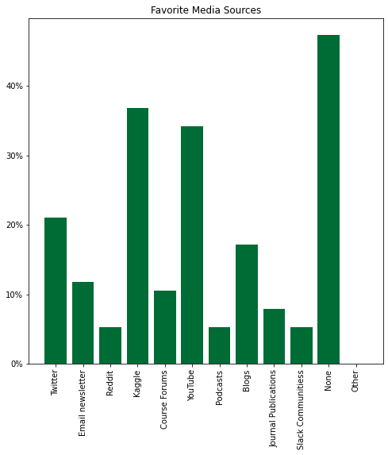

```python
# Show favorite media sources bar chart
plt.figure(figsize = (8,8))
plt.bar(media['Media'], media['Frequency'], color = '#006C35')
plt.gca().yaxis.set_major_formatter(ticker.PercentFormatter(decimals=0.5))
plt.title('Favorite Media Sources')
plt.xticks(rotation=90)
plt.show()
```

## 3. Data Science and Machine Learning Experience

### 3.1. Programming Experience

```python
# Create a data frame for programming experience year
prog_exp = pd.DataFrame(saudi_df2020.groupby('Q6').count()['Q2']).reset_index()
custom_dict = {'< 1 years':0, '1-2 years':1, '3-5 years':2, '5-10 years':3, '10-20 years':4, '20+ years':5,
               'I have never written code':6}
prog_exp['rank'] = prog_exp['Q6'].map(custom_dict)
prog_exp.sort_values(by = ['rank'], inplace=True)
prog_exp = prog_exp.drop(labels=['rank'],axis=1)
prog_exp
```

|  | Q6 | Q2 |
| --- | --- | --- |
| 5 | < 1 years | 18 |
| 0 | 1-2 years | 5 |
| 3 | 3-5 years | 14 |
| 4 | 5-10 years | 12 |
| 1 | 10-20 years | 8 |
| 2 | 20+ years | 2 |
| 6 | I have never written code | 15 |

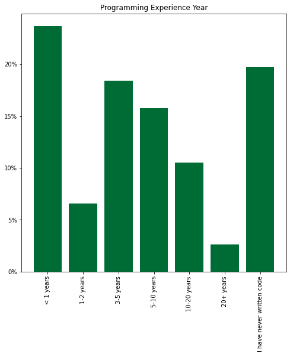

```python
# Show programming experience year bar chart
plt.figure(figsize = (8,8))
plt.bar(prog_exp['Q6'], prog_exp['Q2']/saudi_df2020.shape[0]*100, color = '#006C35')
plt.gca().yaxis.set_major_formatter(ticker.PercentFormatter(decimals=0.5))
plt.title('Programming Experience Year')
plt.xticks(rotation=90)
plt.show()
```

In the data science community, there are experts and beginners. Most of the participants have a good background in programming. 23% of the participants have less than one year of programming experience, and 19% of them stated that they have never written code.

### 3.2. Machine Learning Experience

```python
# Create a data frame for machine learning experience year
ml_exp = pd.DataFrame(saudi_df2020.groupby('Q15').count()['Q2']).reset_index()
custom_dict = {'Under 1 year':0, '1-2 years':1, '2-3 years':2, '3-4 years':3, '4-5 years':4, '5-10 years':5, '10-20 years':6,
               '20 or more years':7, 'I do not use machine learning methods':8}
ml_exp['rank'] = ml_exp['Q15'].map(custom_dict)
ml_exp.sort_values(by = ['rank'], inplace=True)
ml_exp = ml_exp.drop(labels=['rank'],axis=1)
ml_exp
```

|  | Q15 | Q2 |
| --- | --- | --- |
| 6 | Under 1 year | 18 |
| 0 | 1-2 years | 9 |
| 2 | 2-3 years | 5 |
| 3 | 4-5 years | 2 |
| 4 | 5-10 years | 1 |
| 1 | 10-20 years | 1 |
| 5 | I do not use machine learning methods | 14 |

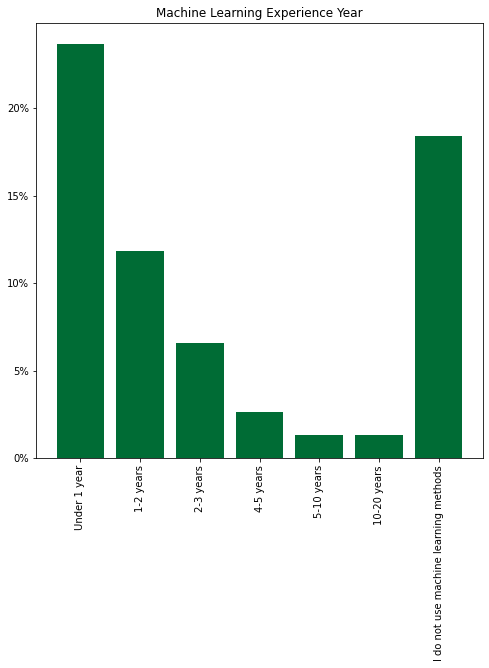

```python
# Show machine learning experience year bar chart
plt.figure(figsize = (8,8))
plt.bar(ml_exp['Q15'], ml_exp['Q2']/saudi_df2020.shape[0]*100, color = '#006C35')
plt.gca().yaxis.set_major_formatter(ticker.PercentFormatter(decimals=0.5))
plt.title('Machine Learning Experience Year')
plt.xticks(rotation=90)
plt.show()
```

In general, the participants are new to machine learning algorithms. Most of the participants have less than one year of experience in machine learning algorithms and their percentage is 23%. 18% of the participants have never used machine learning algorithms. Only 4% of the participants have more than 4 years' experience in machine learning algorithms, and compared to the rest of the world, 10 % Of them have more than 4 years' experience in machine learning.

## 4. Employment

### 4.1. Job Role

```python
# Create a data frame for job roles
role = pd.DataFrame(saudi_df2020.groupby(['Q5']).count()['Q2']).reset_index()
# Sort dataframe
role = role.sort_values('Q2')
role
```

|  | Q5 | Q2 |
| --- | --- | --- |
| 4 | Machine Learning Engineer | 3 |
| 6 | Product/Project Manager | 3 |
| 0 | Business Analyst | 6 |
| 8 | Software Engineer | 6 |
| 7 | Research Scientist | 8 |
| 2 | Data Analyst | 9 |
| 9 | Student | 9 |
| 1 | Currently not employed | 10 |
| 5 | Other | 10 |
| 3 | Data Scientist | 11 |

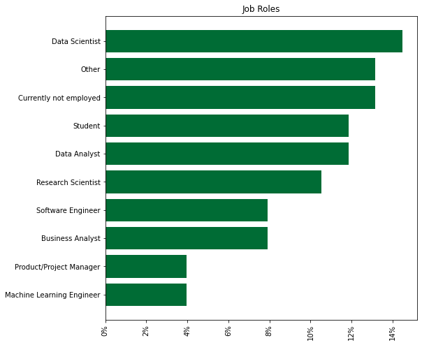

```python
# Show job roles bar chart
plt.figure(figsize = (8,8))
plt.barh(role['Q5'], role['Q2']/saudi_df2020.shape[0]*100, color = '#006C35')
plt.gca().xaxis.set_major_formatter(ticker.PercentFormatter(decimals=0.5))
plt.title('Job Roles')
plt.xticks(rotation=90)
plt.show()
```

The real job roles of participants are different. The largest percentage of them work as data scientists (14%). As for machine learning engineers, they are only 4%. 12% of the participants are data analysts and 10% of them are researchers. Also, there are some participants do not work because they are students (11%) or are not currently employed (13%).

### 4.3. Company Size

```python
# Create a dataframe for company size
company = pd.DataFrame(saudi_df2020.groupby('Q20').count()['Q2']).reset_index()
custom_dict = {'0-49 employees':0, '50-249 employees':1, '250-999 employees':2, '1000-9,999 employees':3, '10,000 or more employees':4, '5,000-7,499':5, '10,000-14,999':6 }
company['rank'] = company['Q20'].map(custom_dict)
company.sort_values(by = ['rank'], inplace=True)
company = company.drop(labels=['rank'],axis=1)
company
```

|  | Q20 | Q2 |
| --- | --- | --- |
| 0 | 0-49 employees | 16 |
| 4 | 50-249 employees | 8 |
| 3 | 250-999 employees | 9 |
| 2 | 1000-9,999 employees | 10 |
| 1 | 10,000 or more employees | 7 |

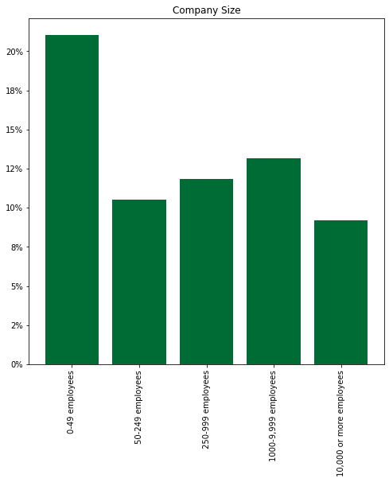

```python
# Show company size bar chart
plt.figure(figsize = (8,8))
plt.bar(company['Q20'], company['Q2']/saudi_df2020.shape[0]*100, color = '#006C35')
plt.gca().yaxis.set_major_formatter(ticker.PercentFormatter(decimals=0.5))
plt.title('Company Size')
plt.xticks(rotation=90)
plt.show()
```

When participants were asked about the size of the company where they work for; Most of them answered that they work for a small-sized company with fewer than 50 employees.

### 4.4. Data Science Team Size

```python
# Create a data frame for team size
ds_team = pd.DataFrame(saudi_df2020.groupby('Q21').count()['Q2']).reset_index()
custom_dict = {'0':0, '1-2':1, '3-4':2, '5-9':3, '10-14':4, '15-19':5, '20+':6 }
ds_team['rank'] = ds_team['Q21'].map(custom_dict)
ds_team.sort_values(by = ['rank'], inplace=True)
ds_team = ds_team.drop(labels=['rank'],axis=1)
ds_team
```

|  | Q21 | Q2 |
| --- | --- | --- |
| 0 | 0 | 14 |
| 1 | 1-2 | 11 |
| 5 | 3-4 | 8 |
| 6 | 5-9 | 8 |
| 2 | 10-14 | 1 |
| 3 | 15-19 | 3 |
| 4 | 20+ | 5 |

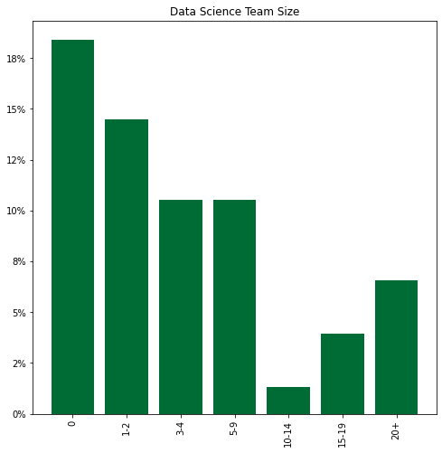

```python
# Show team size bar chart
plt.figure(figsize = (8,8))
plt.bar(ds_team['Q21'], ds_team['Q2']/saudi_df2020.shape[0]*100, color = '#006C35')
plt.gca().yaxis.set_major_formatter(ticker.PercentFormatter(decimals=0.5))
plt.title('Data Science Team Size')
plt.xticks(rotation=90)
plt.show()
```

We can see that 6% of the participants work in teams of 20 or more members. We also can see that approximately 25% of the participants work in teams of less than five people. Moreover, 18% of the participants reported that their team size is zero.

### 4.5. Using Machine Learning the Company

```python
# Create a data frame for how companies adopt machine learning
use_ml = pd.DataFrame(saudi_df2020.groupby('Q22').count()['Q2']/saudi_df2020.shape[0]*100).reset_index()
# Sort dataframe
use_ml = use_ml.sort_values('Q22')
use_ml
```

|  | Q22 | Q2 |
| --- | --- | --- |
| 0 | I do not know | 15.789474 |
| 1 | No (we do not use ML methods) | 26.315789 |
| 2 | We are exploring ML methods (and may one day p... | 11.842105 |
| 3 | We have well established ML methods (i.e., mod... | 2.631579 |
| 4 | We recently started using ML methods (i.e., mo... | 3.947368 |
| 5 | We use ML methods for generating insights (but... | 2.631579 |

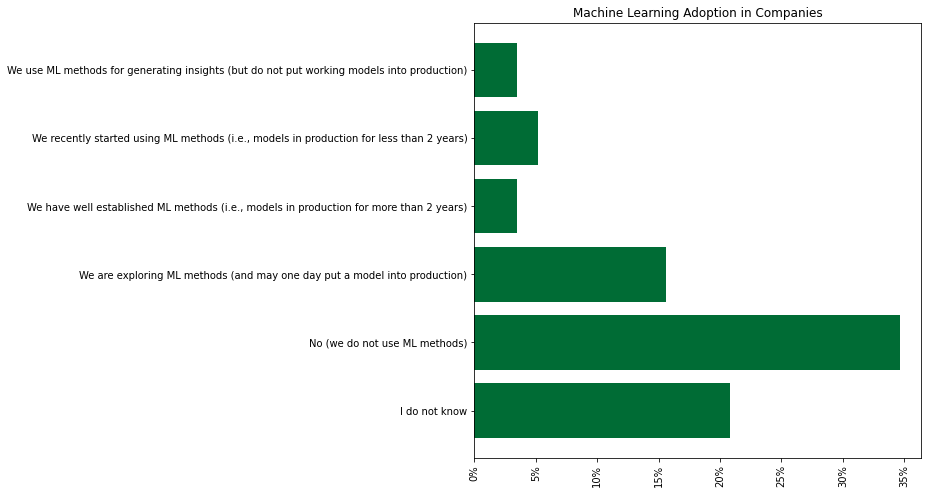

```python
# Show a bar chart for machine learning adoption in companies
plt.figure(figsize = (8,8))
plt.barh(use_ml['Q22'], use_ml['Q2']/saudi_df2020.shape[0]*100, color = '#006C35')
plt.gca().xaxis.set_major_formatter(ticker.PercentFormatter(decimals=0.5))
plt.title('Machine Learning Adoption in Companies')
plt.xticks(rotation=90)
plt.show()
```

More than 25% of respondents stated that their company have not used machine learning methods. Nearly 4% stated that their companies recently started using machine learning methods, while 11% of respondents stated that they are exploring machine learning methods and may one day put a model into production. The respondents who work in companies that have well established ML methods and use models in production for more than 2 years are only 2%.

## 5. Technology

### 5.1. Integrated Development Environments (IDE)

```python
#Create a data frame for IDEs
ide_list = ['JupyterLab', 'RStudio', 'Visual Studio','Visual Studio Code','PyCharm','Spyder', 'Notepad++',
 'Sublime Text', 'Vim, Emacs, or similar', 'MATLAB', 'None', 'Other']

count_list = [saudi_df2020['Q9_Part_1'].count()/saudi_df2020.shape[0]*100,
              saudi_df2020['Q9_Part_2'].count()/saudi_df2020.shape[0]*100,
              saudi_df2020['Q9_Part_3'].count()/saudi_df2020.shape[0]*100,
              saudi_df2020['Q9_Part_4'].count()/saudi_df2020.shape[0]*100,
              saudi_df2020['Q9_Part_5'].count()/saudi_df2020.shape[0]*100,
              saudi_df2020['Q9_Part_6'].count()/saudi_df2020.shape[0]*100,
              saudi_df2020['Q9_Part_7'].count()/saudi_df2020.shape[0]*100,
              saudi_df2020['Q9_Part_8'].count()/saudi_df2020.shape[0]*100,
              saudi_df2020['Q9_Part_9'].count()/saudi_df2020.shape[0]*100,
              saudi_df2020['Q9_Part_10'].count()/saudi_df2020.shape[0]*100,
              saudi_df2020['Q9_Part_11'].count()/saudi_df2020.shape[0]*100,
              saudi_df2020['Q9_OTHER'].count()/saudi_df2020.shape[0]*100]

ide = pd.DataFrame({'IDE':ide_list, 'Frequency': count_list})
ide
```

|  | IDE | Frequency |
| --- | --- | --- |
| 0 | JupyterLab | 43.421053 |
| 1 | RStudio | 5.263158 |
| 2 | Visual Studio | 11.842105 |
| 3 | Visual Studio Code | 25.000000 |
| 4 | PyCharm | 11.842105 |
| 5 | Spyder | 13.157895 |
| 6 | Notepad++ | 9.210526 |
| 7 | Sublime Text | 0.000000 |
| 8 | Vim, Emacs, or similar | 0.000000 |
| 9 | MATLAB | 9.210526 |
| 10 | None | 1.315789 |
| 11 | Other | 3.947368 |

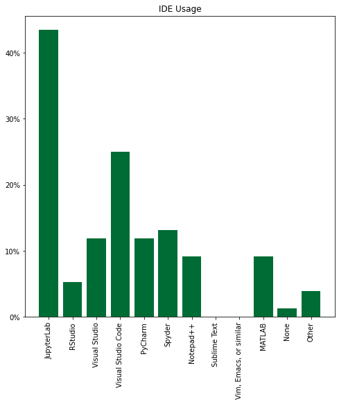

```python
# Show a bar chart for IDEs
plt.figure(figsize = (8,8))
plt.bar(ide['IDE'], ide['Frequency'], color = '#006C35')
plt.gca().yaxis.set_major_formatter(ticker.PercentFormatter(decimals=0.5))
plt.title('IDE Usage')
plt.xticks(rotation=90)
plt.show()
```

### 5.2. Data Analysis Tools

```python
#fill empty field with None
for i in range(len(saudi_df2020)):
    if (pd.isnull(saudi_df2020.loc[i, 'Q38'])):
        saudi_df2020.loc[i, 'Q38'] = 'None'
```

```python
# Create a data frame for data analysis tools
da_tool = pd.DataFrame(saudi_df2020.groupby('Q38').count()['Q2']/saudi_df2020.shape[0]*100).reset_index()
# Sort dataframe
da_tool = da_tool.sort_values('Q38')
da_tool
```

|  | Q38 | Q2 |
| --- | --- | --- |
| 0 | Advanced statistical software (SPSS, SAS, etc.) | 1.315789 |
| 1 | Basic statistical software (Microsoft Excel, G... | 35.526316 |
| 2 | Business intelligence software (Salesforce, Ta... | 2.631579 |
| 3 | Cloud-based data software & APIs (AWS, GCP, Az... | 1.315789 |
| 4 | Local development environments (RStudio, Jupyt... | 17.105263 |
| 5 | None | 42.105263 |

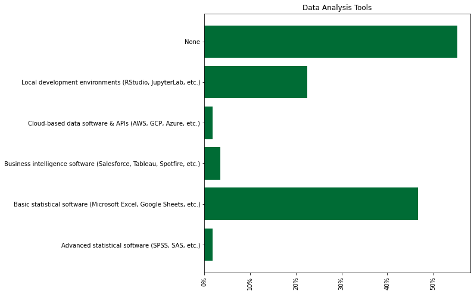

```python
# Show a bar chart for data analysis
plt.figure(figsize = (8,8))
plt.barh(da_tool['Q38'], da_tool['Q2']/saudi_df2020.shape[0]*100, color = '#006C35')
plt.gca().xaxis.set_major_formatter(ticker.PercentFormatter(decimals=0.5))
plt.title('Data Analysis Tools')
plt.xticks(rotation=90)
plt.show()
```

### 5.3. Machine Learning Algorithms

```python
#Create a data frame for machine learning algorithms
ml_alg_list = ['Linear or Logistic Regression', 'Decision Trees or Random Forests', 'Gradient Boosting Machines','Bayesian Approaches',
           'Evolutionary Approaches','Dense Neural Networks', 'Convolutional Neural Networks',
 'Generative Adversarial Networks', 'Recurrent Neural Networks', 'Transformer Networks', 'None', 'Other']

count_list = [saudi_df2020['Q17_Part_1'].count()/saudi_df2020.shape[0]*100,
              saudi_df2020['Q17_Part_2'].count()/saudi_df2020.shape[0]*100,
              saudi_df2020['Q17_Part_3'].count()/saudi_df2020.shape[0]*100,
              saudi_df2020['Q17_Part_4'].count()/saudi_df2020.shape[0]*100,
              saudi_df2020['Q17_Part_5'].count()/saudi_df2020.shape[0]*100,
              saudi_df2020['Q17_Part_6'].count()/saudi_df2020.shape[0]*100,
              saudi_df2020['Q17_Part_7'].count()/saudi_df2020.shape[0]*100,
              saudi_df2020['Q17_Part_8'].count()/saudi_df2020.shape[0]*100,
              saudi_df2020['Q17_Part_9'].count()/saudi_df2020.shape[0]*100,
              saudi_df2020['Q17_Part_10'].count()/saudi_df2020.shape[0]*100,
              saudi_df2020['Q17_Part_11'].count()/saudi_df2020.shape[0]*100,
              saudi_df2020['Q17_OTHER'].count()/saudi_df2020.shape[0]*100]

ml_alg = pd.DataFrame({'ML Algorithm':ml_alg_list, 'Frequency': count_list})
ml_alg
```

|  | ML Algorithm | Frequency |
| --- | --- | --- |
| 0 | Linear or Logistic Regression | 30.263158 |
| 1 | Decision Trees or Random Forests | 22.368421 |
| 2 | Gradient Boosting Machines | 7.894737 |
| 3 | Bayesian Approaches | 6.578947 |
| 4 | Evolutionary Approaches | 2.631579 |
| 5 | Dense Neural Networks | 5.263158 |
| 6 | Convolutional Neural Networks | 21.052632 |
| 7 | Generative Adversarial Networks | 2.631579 |
| 8 | Recurrent Neural Networks | 5.263158 |
| 9 | Transformer Networks | 3.947368 |
| 10 | None | 5.263158 |
| 11 | Other | 1.315789 |

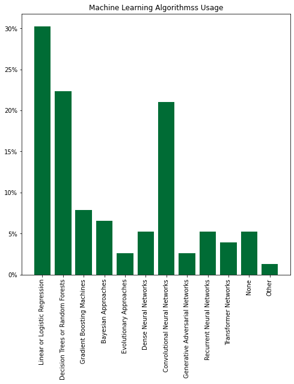

```python
# Show a bar chart for machine learning algorithms
plt.figure(figsize = (8,8))
plt.bar(ml_alg['ML Algorithm'], ml_alg['Frequency'], color = '#006C35')
plt.gca().yaxis.set_major_formatter(ticker.PercentFormatter(decimals=0.5))
plt.title('Machine Learning Algorithmss Usage')
plt.xticks(rotation=90)
plt.show()
```

Participants usually use simple algorithms and complex algorithms. The most commonly used algorithms are Linear Regression and Logistic Regression, followed by Decision Trees and Random Forest, followed by Convolutional Neural Networks algorithm. It is considered one of the most popular complex algorithms among participants.

### 5.4. Machine Learning Platforms

```python
#Create a data frame for machine learning platforms
ml_pf_list = ['Scikit-learn', 'TensorFlow', 'Keras',' PyTorch', 'Fast.ai','MXNet', 'Xgboost',
 'LightGBM', 'CatBoost', 'Prophet', 'H2O 3', 'Caret', 'Tidymodels', 'JAX', 'None', 'Other']

count_list = [saudi_df2020['Q16_Part_1'].count()/saudi_df2020.shape[0]*100,
              saudi_df2020['Q16_Part_2'].count()/saudi_df2020.shape[0]*100,
              saudi_df2020['Q16_Part_3'].count()/saudi_df2020.shape[0]*100,
              saudi_df2020['Q16_Part_4'].count()/saudi_df2020.shape[0]*100,
              saudi_df2020['Q16_Part_5'].count()/saudi_df2020.shape[0]*100,
              saudi_df2020['Q16_Part_6'].count()/saudi_df2020.shape[0]*100,
              saudi_df2020['Q16_Part_7'].count()/saudi_df2020.shape[0]*100,
              saudi_df2020['Q16_Part_8'].count()/saudi_df2020.shape[0]*100,
              saudi_df2020['Q16_Part_9'].count()/saudi_df2020.shape[0]*100,
              saudi_df2020['Q16_Part_10'].count()/saudi_df2020.shape[0]*100,
              saudi_df2020['Q16_Part_11'].count()/saudi_df2020.shape[0]*100,
              saudi_df2020['Q16_Part_12'].count()/saudi_df2020.shape[0]*100,
              saudi_df2020['Q16_Part_13'].count()/saudi_df2020.shape[0]*100,
              saudi_df2020['Q16_Part_14'].count()/saudi_df2020.shape[0]*100,
              saudi_df2020['Q16_Part_15'].count()/saudi_df2020.shape[0]*100,
              saudi_df2020['Q16_OTHER'].count()/saudi_df2020.shape[0]*100]

ml_pf = pd.DataFrame({'ML Platform':ml_pf_list, 'Frequency': count_list})
ml_pf
```

|  | ML Platform | Frequency |
| --- | --- | --- |
| 0 | Scikit-learn | 30.263158 |
| 1 | TensorFlow | 19.736842 |
| 2 | Keras | 17.105263 |
| 3 | PyTorch | 10.526316 |
| 4 | Fast.ai | 0.000000 |
| 5 | MXNet | 2.631579 |
| 6 | Xgboost | 6.578947 |
| 7 | LightGBM | 0.000000 |
| 8 | CatBoost | 1.315789 |
| 9 | Prophet | 0.000000 |
| 10 | H2O 3 | 1.315789 |
| 11 | Caret | 0.000000 |
| 12 | Tidymodels | 0.000000 |
| 13 | JAX | 0.000000 |
| 14 | None | 5.263158 |
| 15 | Other | 1.315789 |

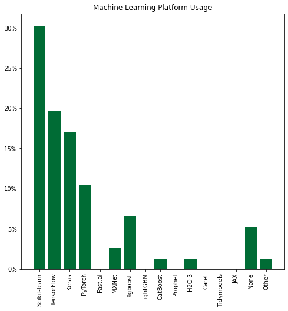

```python
# Show a bar chart for machine learning platforms
plt.figure(figsize = (8,8))
plt.bar(ml_pf['ML Platform'], ml_pf['Frequency'], color = '#006C35')
plt.gca().yaxis.set_major_formatter(ticker.PercentFormatter(decimals=0.5))
plt.title('Machine Learning Platform Usage')
plt.xticks(rotation=90)
plt.show()
```

Regarding the machine learning platforms that participants usually use, the Scikit-learn platform is one of the most used platforms, it is followed by TensorFlow, Keras, and PyTorch which are used to build neural networks.

### 5.5. Cloud Computing Platforms

```python
#fill empty field with None
for i in range(len(saudi_df2020)):
    if (pd.isnull(saudi_df2020.loc[i, 'Q26_A_Part_1']) & pd.isnull(saudi_df2020.loc[i, 'Q26_A_Part_2'])
       & pd.isnull(saudi_df2020.loc[i, 'Q26_A_Part_3'])& pd.isnull(saudi_df2020.loc[i, 'Q26_A_Part_4'])
       & pd.isnull(saudi_df2020.loc[i, 'Q26_A_Part_5'])& pd.isnull(saudi_df2020.loc[i, 'Q26_A_Part_6'])
       & pd.isnull(saudi_df2020.loc[i, 'Q26_A_Part_7'])& pd.isnull(saudi_df2020.loc[i, 'Q26_A_Part_8'])
       & pd.isnull(saudi_df2020.loc[i, 'Q26_A_Part_9'])& pd.isnull(saudi_df2020.loc[i, 'Q26_A_Part_10'])
       & pd.isnull(saudi_df2020.loc[i, 'Q26_A_Part_11'])& pd.isnull(saudi_df2020.loc[i, 'Q26_A_OTHER'])):
        saudi_df2020.loc[i, 'Q26_A_Part_11'] = 'None'
```

```python
#Create a data frame for cloud computing platforms
cloud_pf_list = ['Amazon Web Services', 'Microsoft Azure', 'Google Cloud Platform','IBM Cloud / Red Hat',
              'Oracle Cloud','SAP Cloud', 'Salesforce Cloud', 'VMware Cloud', 'Alibaba Cloud', 'Tencent Cloud',
              'None', 'Other']

count_list = [saudi_df2020['Q26_A_Part_1'].count()/saudi_df2020.shape[0]*100,
              saudi_df2020['Q26_A_Part_2'].count()/saudi_df2020.shape[0]*100,
              saudi_df2020['Q26_A_Part_3'].count()/saudi_df2020.shape[0]*100,
              saudi_df2020['Q26_A_Part_4'].count()/saudi_df2020.shape[0]*100,
              saudi_df2020['Q26_A_Part_5'].count()/saudi_df2020.shape[0]*100,
              saudi_df2020['Q26_A_Part_6'].count()/saudi_df2020.shape[0]*100,
              saudi_df2020['Q26_A_Part_7'].count()/saudi_df2020.shape[0]*100,
              saudi_df2020['Q26_A_Part_8'].count()/saudi_df2020.shape[0]*100,
              saudi_df2020['Q26_A_Part_9'].count()/saudi_df2020.shape[0]*100,
              saudi_df2020['Q26_A_Part_10'].count()/saudi_df2020.shape[0]*100,
              saudi_df2020['Q26_A_Part_11'].count()/saudi_df2020.shape[0]*100,
              saudi_df2020['Q26_A_OTHER'].count()/saudi_df2020.shape[0]*100]

cloud_pf = pd.DataFrame({'Cloud Platform':cloud_pf_list, 'Frequency': count_list})
cloud_pf
```

|  | Cloud Platform | Frequency |
| --- | --- | --- |
| 0 | Amazon Web Services | 9.210526 |
| 1 | Microsoft Azure | 7.894737 |
| 2 | Google Cloud Platform | 6.578947 |
| 3 | IBM Cloud / Red Hat | 2.631579 |
| 4 | Oracle Cloud | 2.631579 |
| 5 | SAP Cloud | 1.315789 |
| 6 | Salesforce Cloud | 2.631579 |
| 7 | VMware Cloud | 2.631579 |
| 8 | Alibaba Cloud | 0.000000 |
| 9 | Tencent Cloud | 0.000000 |
| 10 | None | 76.315789 |
| 11 | Other | 0.000000 |

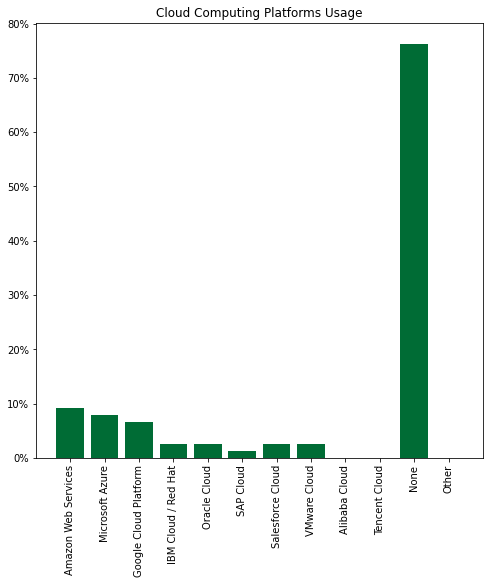

```python
# Show a bar chart for cloud computing platforms
plt.figure(figsize = (8,8))
plt.bar(cloud_pf['Cloud Platform'], cloud_pf['Frequency'], color = '#006C35')
plt.gca().yaxis.set_major_formatter(ticker.PercentFormatter(decimals=0.5))
plt.title('Cloud Computing Platforms Usage')
plt.xticks(rotation=90)
plt.show()
```

### 5.6. Data Visualization Libraries

```python
#Create a data frame for data visualization tools
viz_list = ['Matplotlib', 'Seaborn', 'Plotly / Plotly Express','Ggplot / ggplot2','Shiny','D3 js', 'Altair',
 'Bokeh', 'Geoplotlib', 'Leaflet / Folium', 'None', 'Other']

count_list = [saudi_df2020['Q14_Part_1'].count()/saudi_df2020.shape[0]*100,
              saudi_df2020['Q14_Part_2'].count()/saudi_df2020.shape[0]*100,
              saudi_df2020['Q14_Part_3'].count()/saudi_df2020.shape[0]*100,
              saudi_df2020['Q14_Part_4'].count()/saudi_df2020.shape[0]*100,
              saudi_df2020['Q14_Part_5'].count()/saudi_df2020.shape[0]*100,
              saudi_df2020['Q14_Part_6'].count()/saudi_df2020.shape[0]*100,
              saudi_df2020['Q14_Part_7'].count()/saudi_df2020.shape[0]*100,
              saudi_df2020['Q14_Part_8'].count()/saudi_df2020.shape[0]*100,
              saudi_df2020['Q14_Part_9'].count()/saudi_df2020.shape[0]*100,
              saudi_df2020['Q14_Part_10'].count()/saudi_df2020.shape[0]*100,
              saudi_df2020['Q14_Part_11'].count()/saudi_df2020.shape[0]*100,
              saudi_df2020['Q14_OTHER'].count()/saudi_df2020.shape[0]*100]

viz = pd.DataFrame({'Visualization Library':viz_list, 'Frequency': count_list})
viz
```

|  | Visualization Library | Frequency |
| --- | --- | --- |
| 0 | Matplotlib | 46.052632 |
| 1 | Seaborn | 30.263158 |
| 2 | Plotly / Plotly Express | 10.526316 |
| 3 | Ggplot / ggplot2 | 9.210526 |
| 4 | Shiny | 0.000000 |
| 5 | D3 js | 2.631579 |
| 6 | Altair | 0.000000 |
| 7 | Bokeh | 6.578947 |
| 8 | Geoplotlib | 1.315789 |
| 9 | Leaflet / Folium | 2.631579 |
| 10 | None | 15.789474 |
| 11 | Other | 1.315789 |

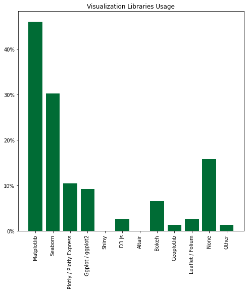

```python
# Show a bar chart for visualization tools
plt.figure(figsize = (8,8))
plt.bar(viz['Visualization Library'], viz['Frequency'], color = '#006C35')
plt.gca().yaxis.set_major_formatter(ticker.PercentFormatter(decimals=0.5))
plt.title('Visualization Libraries Usage')
plt.xticks(rotation=90)
plt.show()
```

About half of the participants use Matplotlib to visualize data, while the Seaborn library is used by almost 30% of the participants, and there is a group of participants (15%) who do not usually use any library to visualize data.

### 5.7. Business Intelligence Tools

```python
#fill empty field with None
for i in range(len(saudi_df2020)):
    if (pd.isnull(saudi_df2020.loc[i, 'Q31_A_Part_1']) & pd.isnull(saudi_df2020.loc[i, 'Q31_A_Part_2'])
       & pd.isnull(saudi_df2020.loc[i, 'Q31_A_Part_3'])& pd.isnull(saudi_df2020.loc[i, 'Q31_A_Part_4'])
       & pd.isnull(saudi_df2020.loc[i, 'Q31_A_Part_5'])& pd.isnull(saudi_df2020.loc[i, 'Q31_A_Part_6'])
       & pd.isnull(saudi_df2020.loc[i, 'Q31_A_Part_7'])& pd.isnull(saudi_df2020.loc[i, 'Q31_A_Part_8'])
       & pd.isnull(saudi_df2020.loc[i, 'Q31_A_Part_9'])& pd.isnull(saudi_df2020.loc[i, 'Q31_A_Part_10'])
       & pd.isnull(saudi_df2020.loc[i, 'Q31_A_Part_11'])& pd.isnull(saudi_df2020.loc[i, 'Q31_A_Part_12'])
       & pd.isnull(saudi_df2020.loc[i, 'Q31_A_Part_13'])& pd.isnull(saudi_df2020.loc[i, 'Q31_A_Part_14'])
       & pd.isnull(saudi_df2020.loc[i, 'Q31_A_OTHER'])):
        saudi_df2020.loc[i, 'Q31_A_Part_14'] = 'None'
```

```python
#Create a data frame for business intelligence tools
bi_tools_list = ['Amazon QuickSight', 'Microsoft Power BI', 'Google Data Studio','Looker','Tableau','Salesforce',
                   'Einstein Analytics', 'Qlik', 'Domo', 'TIBCO Spotfire', 'Alteryx', 'Sisense', 'SAP Analytics Cloud',
                   'None', 'Other']

count_list = [saudi_df2020['Q31_A_Part_1'].count()/saudi_df2020.shape[0]*100,
              saudi_df2020['Q31_A_Part_2'].count()/saudi_df2020.shape[0]*100,
              saudi_df2020['Q31_A_Part_3'].count()/saudi_df2020.shape[0]*100,
              saudi_df2020['Q31_A_Part_4'].count()/saudi_df2020.shape[0]*100,
              saudi_df2020['Q31_A_Part_5'].count()/saudi_df2020.shape[0]*100,
              saudi_df2020['Q31_A_Part_6'].count()/saudi_df2020.shape[0]*100,
              saudi_df2020['Q31_A_Part_7'].count()/saudi_df2020.shape[0]*100,
              saudi_df2020['Q31_A_Part_8'].count()/saudi_df2020.shape[0]*100,
              saudi_df2020['Q31_A_Part_9'].count()/saudi_df2020.shape[0]*100,
              saudi_df2020['Q31_A_Part_10'].count()/saudi_df2020.shape[0]*100,
              saudi_df2020['Q31_A_Part_11'].count()/saudi_df2020.shape[0]*100,
              saudi_df2020['Q31_A_Part_12'].count()/saudi_df2020.shape[0]*100,
              saudi_df2020['Q31_A_Part_13'].count()/saudi_df2020.shape[0]*100,
              saudi_df2020['Q31_A_Part_14'].count()/saudi_df2020.shape[0]*100,
              saudi_df2020['Q31_A_OTHER'].count()/saudi_df2020.shape[0]*100]

bi_tools = pd.DataFrame({'BI Tools':bi_tools_list, 'Frequency': count_list})
bi_tools
```

|  | BI Tools | Frequency |
| --- | --- | --- |
| 0 | Amazon QuickSight | 1.315789 |
| 1 | Microsoft Power BI | 9.210526 |
| 2 | Google Data Studio | 3.947368 |
| 3 | Looker | 0.000000 |
| 4 | Tableau | 10.526316 |
| 5 | Salesforce | 1.315789 |
| 6 | Einstein Analytics | 0.000000 |
| 7 | Qlik | 2.631579 |
| 8 | Domo | 0.000000 |
| 9 | TIBCO Spotfire | 0.000000 |
| 10 | Alteryx | 1.315789 |
| 11 | Sisense | 0.000000 |
| 12 | SAP Analytics Cloud | 3.947368 |
| 13 | None | 78.947368 |
| 14 | Other | 1.315789 |

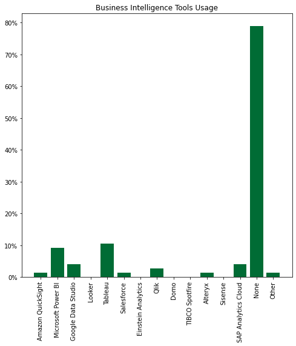

```python
# Show a bar chart for business intelligence tools
plt.figure(figsize = (8,8))
plt.bar(bi_tools['BI Tools'], bi_tools['Frequency'], color = '#006C35')
plt.gca().yaxis.set_major_formatter(ticker.PercentFormatter(decimals=0.5))
plt.title('Business Intelligence Tools Usage')
plt.xticks(rotation=90)
plt.show()
```

Although business intelligence tools help data scientists and analysts to visualize their data, 78% of respondents do not usually use them. The largest percentage of those who use business intelligence tools use Tableau or / and Microsoft Power BI.

# Summary

This report contains insights on the state of the data science and machine learning field in Saudi Arabia in 2020. The insights were collected from the "2020 Kaggle Machine Learning & Data Science Survey". The report presents information about the respondents' skills, education, jobs, and the techniques they use to do the work.